# Exercise 10: Genetic Correlation

## 3. Analyse and present results

### 3.1 Result table

If you open the log files generated in the previous section, you can see that they contain a lot of information, including the genetic correlation (rg) that we will extract for each pair of traits and present in a table.

```python
#Create a list with the file paths ----> Adapt this section based on how you named the files
path_list = ["output/ldsc/adhd_bmi_rg.log",
             "output/ldsc/adhd_edu_rg.log",
             "output/ldsc/adhd_yearfb_rg.log",
             "output/ldsc/adhd_depression_rg.log"]

#Create a list of trait names
trait_list = ["bmi", "educational_attainment", "year_first_birth", "depression"]

#Initiate an empty list
rows = []

#We iterate over all the files
for i in range(len(path_list)):

    #Initiate the result vector
    data = {
        "trait1": "adhd",
        "trait2": trait_list[i],
        "rg": None,
        "se": None,
        "p-value": None
    }

    # Read the file and extract rg, se and p-value
    with open(path_list[i], "r") as f:
        for j, line in enumerate(f):
            if j == 54:
                words = line.strip().split()

                # Extract 3th and 4th "words" (indices 2 and 3) -> corresponds to rg and se
                data["rg"] = float(words[2])
                data["se"] = float(words[3].strip("()"))

            elif j == 56:
                words = line.strip().split()

                #Extract the 2nd "word" (indice 1) -> corresponds to the p-value
                data["p-value"] = float(words[1])

                break # no need to continue reading the file

        #Store in rows
        rows.append(data)



# Store in a DataFrame
df = pd.DataFrame(rows)

df
```

|  | trait1 | trait2 | rg | se | p-value |
| --- | --- | --- | --- | --- | --- |
| 0 | adhd | bmi | -0.0414 | 0.0160 | 9.600000e-03 |
| 1 | adhd | educational_attainment | -0.5218 | 0.0203 | 4.383400e-146 |
| 2 | adhd | year_first_birth | -0.6562 | 0.0227 | 9.022200e-184 |
| 3 | adhd | depression | 0.5961 | 0.0177 | 5.661300e-248 |

### 3.2 Present results in a figure

From the table we just created, we can now create a figure to represent the results. A common way of representing rg is to use a forest plot.

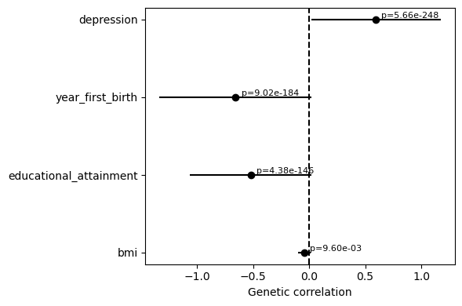

```python
#Create plot
fig,ax = plt.subplots(figsize=(6,4))

#Error bars -> SE
ax.errorbar(
    df["rg"],
    df["trait2"],
    xerr=[abs(df["rg"]-df["se"]), abs(df["rg"]-df["se"])],
    fmt='o',
    color='black',
)

#Vertical line at 0
ax.axvline(0, color='black', linestyle='--')

#Labels on the y-axis
ax.set_yticklabels(df['trait2'])

#Labels on x-axis
ax.set_xlabel("Genetic correlation")

#Add p-value on the right
for i, (_, row) in enumerate(df.iterrows()):
    ax.text(
        row["rg"] + row["se"] + 0.03,
        i,
        f"p={row['p-value']:.2e}",
        va='bottom',
        fontsize=8
    )

plt.tight_layout()
plt.show()
```

**Note**

Based on the result table and the figure, answer the following questions

- Are the results in line with what you expect/the literature?
- Do we need to consider multiple testing? What method can be applied to correct for it? Does it impact the results here?